# Workflow

**1. Human Resources Analytics Solution**

- Define problem
- Metric
- Data Description
- Column Description

**2. EDA and visualization**

- Import all needed packages
- Read in HR data and randomly take 10% out as test data
- Basic of our data
- Check for missing data
- Check skewness for numerical features
- Split the data into numerical and categorical
- Numerical features' correlation
- Other interesting things of the data

**3. Feature Engineering**

- Convert categorical features into numerics
- Split out target

**4. Build model**

- Logstic regresson model
- K-Nearest Neighbors model
- Support vector machine model
- Random Forest model
- XGBoost model
- ROC plot

**5.Summary**

# 1. Human Resources Analytics Solution

**Define problem**

Build model to predict whether the employee left or not by using given data

**Metric**

AUC(Area under the curve)

**Data Description**

Publish with us on Medium at https://medium.com/towards-data-science

Why are our best and most experienced employees leaving prematurely? Have fun with this database and try to predict which valuable employees will leave next. Fields in the dataset include:

Employee satisfaction level Last evaluation Number of projects Average monthly hours Time spent at the company Whether they have had a work accident Whether they have had a promotion in the last 5 years Department Salary Whether the employee has left *This dataset is simulated

**Column Description**

satisfaction_level Level of satisfaction (0-1)

last_evaluation Evaluation of employee performance (0-1)

number_project Number of projects completed while at work

average_montly_hours Average monthly hours at workplace

time_spend_company Number of years spent in the company

Work_accident Whether the employee had a workplace accident

left Whether the employee left the workplace or not (1 or 0) Factor

promotion_last_5years Whether the employee was promoted in the last five years

sales Department in which they work for

salary Relative level of salary (low med high)

# 2.EDA and Visualization

A. Import all needed packages

```python
import pandas as pd
import numpy as np
import seaborn as sns
from scipy.stats import skew
import matplotlib.pyplot as plt
%matplotlib inline
import random

from sklearn.linear_model import LogisticRegression
from sklearn.svm import SVC
from sklearn.ensemble import RandomForestClassifier
from sklearn.neighbors import KNeighborsClassifier
from sklearn.metrics import auc, roc_curve
from scipy import interp
from sklearn.grid_search import GridSearchCV
import xgboost as xgb
```

B. Read in HR data and randomly take 10% out as test data

```python
df=pd.read_csv("/Users/Yasha/Desktop/kaggle/HR.csv")
random_index=random.sample(df.index,1500)
df_test=df.ix[random_index]
df_train=df.drop(random_index)
```

C. Basic of our data

```python
df.info()
print ("Dimension of train data{}".format(df.shape))
df_train.head()
```

```
<class 'pandas.core.frame.DataFrame'>
RangeIndex: 14999 entries, 0 to 14998
Data columns (total 10 columns):
satisfaction_level       14999 non-null float64
last_evaluation          14999 non-null float64
number_project           14999 non-null int64
average_montly_hours     14999 non-null int64
time_spend_company       14999 non-null int64
Work_accident            14999 non-null int64
left                     14999 non-null int64
promotion_last_5years    14999 non-null int64
sales                    14999 non-null object
salary                   14999 non-null object
dtypes: float64(2), int64(6), object(2)
memory usage: 1.1+ MB
Dimension of train data(14999, 10)
```

|  | satisfaction_level | last_evaluation | number_project | average_montly_hours | time_spend_company | Work_accident | left | promotion_last_5years | sales | salary |
| --- | --- | --- | --- | --- | --- | --- | --- | --- | --- | --- |
| 1 | 0.80 | 0.86 | 5 | 262 | 6 | 0 | 1 | 0 | sales | medium |
| 3 | 0.72 | 0.87 | 5 | 223 | 5 | 0 | 1 | 0 | sales | low |
| 5 | 0.41 | 0.50 | 2 | 153 | 3 | 0 | 1 | 0 | sales | low |
| 9 | 0.42 | 0.53 | 2 | 142 | 3 | 0 | 1 | 0 | sales | low |
| 10 | 0.45 | 0.54 | 2 | 135 | 3 | 0 | 1 | 0 | sales | low |

```python
df_train.describe()
```

|  | satisfaction_level | last_evaluation | number_project | average_montly_hours | time_spend_company | Work_accident | left | promotion_last_5years |
| --- | --- | --- | --- | --- | --- | --- | --- | --- |
| count | 13499.000000 | 13499.000000 | 13499.000000 | 13499.000000 | 13499.000000 | 13499.000000 | 13499.000000 | 13499.000000 |
| mean | 0.612789 | 0.715594 | 3.801319 | 200.820357 | 3.503297 | 0.144826 | 0.237795 | 0.021779 |
| std | 0.248464 | 0.171302 | 1.233068 | 49.985979 | 1.469062 | 0.351938 | 0.425749 | 0.145968 |
| min | 0.090000 | 0.360000 | 2.000000 | 96.000000 | 2.000000 | 0.000000 | 0.000000 | 0.000000 |
| 25% | 0.440000 | 0.560000 | 3.000000 | 156.000000 | 3.000000 | 0.000000 | 0.000000 | 0.000000 |
| 50% | 0.640000 | 0.720000 | 4.000000 | 199.000000 | 3.000000 | 0.000000 | 0.000000 | 0.000000 |
| 75% | 0.820000 | 0.870000 | 5.000000 | 245.000000 | 4.000000 | 0.000000 | 0.000000 | 0.000000 |
| max | 1.000000 | 1.000000 | 7.000000 | 310.000000 | 10.000000 | 1.000000 | 1.000000 | 1.000000 |

Comment: data set is small, therefore no need for big data techs or change data type for faster processing

D. Check for missing data

```python
def show_missing():
    missing = df.columns[df.isnull().any()].tolist()
    return missing
df[show_missing()].isnull().sum()
```

```
Series([], dtype: float64)
```

Comment: very good data without missing data

E. Check skewness for numeric data( if absoulte value of skewness of any feature is greater than 0.75, we will use box-cox to transform it)

```python
print 'skewness of satisfaction_level :', skew(df_train['satisfaction_level'])
print 'skewness of last_evaluation :', skew(df_train['last_evaluation'])
print 'skewness of average_montly_hours :', skew(df_train['average_montly_hours'])
```

```
skewness of satisfaction_level : -0.474348052171
skewness of last_evaluation : -0.0239677546597
skewness of average_montly_hours : 0.0617159404974
```

Comment: there is no skewness need to be worried

F. Divide the data as numeric and categorical data

```python
df_num=df_train.loc[:,('satisfaction_level','last_evaluation','number_project','average_montly_hours','time_spend_company')]
df_cate=df_train.loc[:,('Work_accident','promotion_last_5years','sales','salary')]
```

```python
df_cate.describe()
```

|  | Work_accident | promotion_last_5years |
| --- | --- | --- |
| count | 13499.000000 | 13499.000000 |
| mean | 0.144826 | 0.021779 |
| std | 0.351938 | 0.145968 |
| min | 0.000000 | 0.000000 |
| 25% | 0.000000 | 0.000000 |
| 50% | 0.000000 | 0.000000 |
| 75% | 0.000000 | 0.000000 |
| max | 1.000000 | 1.000000 |

G. Numerical features' correlation

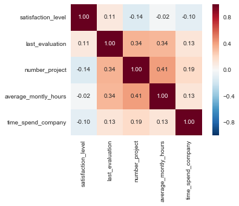

```python
corr_num=df_num.corr()
sns.heatmap(corr_num,square=True,annot=True,fmt='.2f')
```

Comment: need to be aware there is 0.41 between average_monthly_hours and number_project

H. Other interesting things of the data

```python
sales=df_train.groupby('sales').mean()
sales
```

| sales | satisfaction_level | last_evaluation | number_project | average_montly_hours | time_spend_company | Work_accident | left | promotion_last_5years |
| --- | --- | --- | --- | --- | --- | --- | --- | --- |
| IT | 0.620127 | 0.717250 | 3.821234 | 201.550817 | 3.482759 | 0.134301 | 0.226860 | 0.001815 |
| RandD | 0.622582 | 0.710227 | 3.852482 | 201.321986 | 3.402837 | 0.168794 | 0.153191 | 0.035461 |
| accounting | 0.582628 | 0.717727 | 3.832386 | 202.228693 | 3.519886 | 0.119318 | 0.267045 | 0.018466 |
| hr | 0.595827 | 0.704325 | 3.644917 | 197.585736 | 3.359636 | 0.118361 | 0.289833 | 0.021244 |
| management | 0.622895 | 0.724123 | 3.847368 | 200.938596 | 4.315789 | 0.166667 | 0.136842 | 0.112281 |
| marketing | 0.622145 | 0.715330 | 3.690355 | 198.571066 | 3.568528 | 0.166244 | 0.239848 | 0.049492 |
| product_mng | 0.618541 | 0.712126 | 3.803461 | 199.084054 | 3.480841 | 0.149567 | 0.223733 | 0.000000 |
| sales | 0.613272 | 0.708609 | 3.766077 | 200.434352 | 3.531350 | 0.141747 | 0.245981 | 0.024920 |
| support | 0.618866 | 0.724312 | 3.808060 | 201.056927 | 3.407557 | 0.157683 | 0.243829 | 0.009068 |
| technical | 0.606969 | 0.721648 | 3.883436 | 202.481800 | 3.407362 | 0.137832 | 0.254806 | 0.010634 |

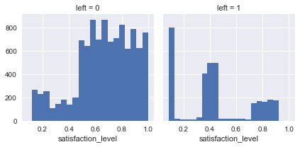

```python
g=sns.FacetGrid(df_train,col='left')
g.map(plt.hist,'satisfaction_level',bins=20)
```

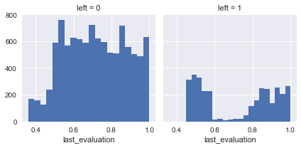

```python
g=sns.FacetGrid(df_train,col='left')
g.map(plt.hist,'last_evaluation',bins=20)
```

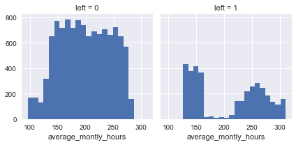

```python
g=sns.FacetGrid(df,col='left')
g.map(plt.hist,'average_montly_hours',bins=20)
```

```python
salary=df.groupby('salary').mean()
salary
```

| salary | satisfaction_level | last_evaluation | number_project | average_montly_hours | time_spend_company | Work_accident | left | promotion_last_5years |
| --- | --- | --- | --- | --- | --- | --- | --- | --- |
| high | 0.637470 | 0.704325 | 3.767179 | 199.867421 | 3.692805 | 0.155214 | 0.066289 | 0.058205 |
| low | 0.600753 | 0.717017 | 3.799891 | 200.996583 | 3.438218 | 0.142154 | 0.296884 | 0.009021 |
| medium | 0.621817 | 0.717322 | 3.813528 | 201.338349 | 3.529010 | 0.145361 | 0.204313 | 0.028079 |

```python
number_project=df.groupby('number_project').mean()
number_project
```

| number_project | satisfaction_level | last_evaluation | average_montly_hours | time_spend_company | Work_accident | left | promotion_last_5years |
| --- | --- | --- | --- | --- | --- | --- | --- |
| 2 | 0.478769 | 0.568505 | 160.342546 | 3.180486 | 0.092965 | 0.656198 | 0.015494 |
| 3 | 0.687670 | 0.716572 | 197.507522 | 3.286560 | 0.175092 | 0.017756 | 0.023428 |
| 4 | 0.695132 | 0.740009 | 205.122108 | 3.454983 | 0.156472 | 0.093700 | 0.026804 |
| 5 | 0.678888 | 0.762010 | 212.061572 | 3.800072 | 0.150670 | 0.221659 | 0.018109 |
| 6 | 0.273458 | 0.786550 | 238.694208 | 4.192504 | 0.114140 | 0.557922 | 0.017036 |
| 7 | 0.118711 | 0.859609 | 276.078125 | 4.113281 | 0.015625 | 1.000000 | 0.000000 |

```python
time_spend_company=df.groupby('time_spend_company').mean()
time_spend_company
```

| time_spend_company | satisfaction_level | last_evaluation | number_project | average_montly_hours | Work_accident | left | promotion_last_5years |
| --- | --- | --- | --- | --- | --- | --- | --- |
| 2 | 0.697078 | 0.717596 | 3.687423 | 200.133169 | 0.172010 | 0.016338 | 0.016646 |
| 3 | 0.626314 | 0.668721 | 3.327798 | 186.632935 | 0.138910 | 0.246159 | 0.020798 |
| 4 | 0.467517 | 0.767927 | 4.627689 | 223.455221 | 0.124364 | 0.348064 | 0.013688 |
| 5 | 0.610305 | 0.813666 | 4.519348 | 222.978955 | 0.116090 | 0.565513 | 0.011541 |
| 6 | 0.603440 | 0.754875 | 4.213092 | 212.051532 | 0.149025 | 0.291086 | 0.023677 |
| 7 | 0.635957 | 0.682766 | 3.851064 | 200.744681 | 0.138298 | 0.000000 | 0.191489 |
| 8 | 0.665062 | 0.711975 | 3.777778 | 193.802469 | 0.271605 | 0.000000 | 0.061728 |
| 10 | 0.655327 | 0.731495 | 3.682243 | 199.224299 | 0.233645 | 0.000000 | 0.074766 |

# 3.Feature Engineering

A. Convert categorical features into numerics

```python
def onehot(data,column_name):
    dummies=pd.get_dummies(data[column_name],prefix="_"+column_name)
    data=data.join(dummies)
    data=data.drop([column_name],axis=1)
    return data
```

```python
df_train=onehot(df_train,'sales')
df_train=onehot(df_train,'salary')
df_test=onehot(df_test,'sales')
df_test=onehot(df_test,'salary')
```

B. Split out target

```python
def separate_x_y(data,col):
    y=data[col]
    data.drop(labels=col,axis=1,inplace=True)
    return data, y
```

```python
train_x,train_y=separate_x_y(df_train,'left')
test_x,test_y=separate_x_y(df_test,'left')
```

# 4.Build Model

A. Build logstic regresson model, use GridSearchCV() to find optimal parameter

```python
LG_para_C=np.arange(0.1,15,0.1)
para_grid={"C":LG_para_C}
clf_lg=LogisticRegression(penalty="l2",solver="liblinear",max_iter=1000)
grid_search=GridSearchCV(estimator=clf_lg,param_grid=para_grid,scoring="roc_auc",n_jobs=-1,cv=5,refit=False,verbose=1)
grid_search.fit(train_x,train_y)
print(grid_search.best_params_)
print(grid_search.best_score_)
```

```
Fitting 5 folds for each of 149 candidates, totalling 745 fits
```

```
[Parallel(n_jobs=-1)]: Done 144 tasks      | elapsed:    2.2s
```

```
{'C': 14.700000000000001}
0.795110427718
```

```
[Parallel(n_jobs=-1)]: Done 745 out of 745 | elapsed:   11.2s finished
```

```python
clf_lg=LogisticRegression(C=14.7,penalty="l2",solver="liblinear",max_iter=1000)
```

```python
clf_lg.fit(train_x,train_y)
```

```
LogisticRegression(C=14.7, class_weight=None, dual=False, fit_intercept=True,
          intercept_scaling=1, max_iter=1000, multi_class='ovr', n_jobs=1,
          penalty='l2', random_state=None, solver='liblinear', tol=0.0001,
          verbose=0, warm_start=False)
```

B. Build knn model,use GridSearchCV() to find optimal parameter

```python
clf_knn=KNeighborsClassifier()
KNN_para_n=np.arange(1,15)
para_grid={"n_neighbors":KNN_para_n}
grid_search=GridSearchCV(estimator=clf_knn,param_grid=para_grid,scoring="roc_auc",n_jobs=-1,cv=5,refit=False,verbose=1)
grid_search.fit(train_x,train_y)
print(grid_search.best_params_)
print(grid_search.best_score_)
```

```
Fitting 5 folds for each of 14 candidates, totalling 70 fits
{'n_neighbors': 9}
0.97132854074
```

```
[Parallel(n_jobs=-1)]: Done  70 out of  70 | elapsed:    1.6s finished
```

```python
clf_knn=KNeighborsClassifier(n_neighbors=9)
```

```python
clf_knn.fit(train_x,train_y)
```

```
KNeighborsClassifier(algorithm='auto', leaf_size=30, metric='minkowski',
           metric_params=None, n_jobs=1, n_neighbors=9, p=2,
           weights='uniform')
```

C. Build svm model,use GridSearchCV() to find optimal parameter

```python
SVM_para_C=np.arange(12,18,0.1)
para_grid={"C":SVM_para_C}
clf_svm=SVC()
grid_search=GridSearchCV(estimator=clf_svm,param_grid=para_grid,scoring="roc_auc",n_jobs=-1,cv=5,refit=False,verbose=1)
grid_search.fit(train_x,train_y)
print(grid_search.best_params_)
print(grid_search.best_score_)
```

```
Fitting 5 folds for each of 60 candidates, totalling 300 fits
```

```
[Parallel(n_jobs=-1)]: Done  42 tasks      | elapsed:   20.4s
[Parallel(n_jobs=-1)]: Done 192 tasks      | elapsed:  1.5min
```

```
{'C': 17.899999999999977}
0.982293568107
```

```
[Parallel(n_jobs=-1)]: Done 300 out of 300 | elapsed:  2.4min finished
```

```python
clf_svm=SVC(C=17.9)
```

```python
clf_svm.fit(train_x,train_y)
```

```
SVC(C=17.9, cache_size=200, class_weight=None, coef0=0.0,
  decision_function_shape=None, degree=3, gamma='auto', kernel='rbf',
  max_iter=-1, probability=False, random_state=None, shrinking=True,
  tol=0.001, verbose=False)
```

D. Build random forest model,use GridSearchCV() to find optimal parameter

```python
clf_rf=RandomForestClassifier()
para_grid={"max_depth":[2,3,4]}
grid_search=GridSearchCV(estimator=clf_rf,param_grid=para_grid,scoring="roc_auc",n_jobs=-1,cv=5,refit=False,verbose=1)
grid_search.fit(train_x,train_y)
print(grid_search.best_params_)
print(grid_search.best_score_)
```

```
Fitting 5 folds for each of 3 candidates, totalling 15 fits
```

```
[Parallel(n_jobs=-1)]: Done   8 out of  15 | elapsed:    0.2s remaining:    0.2s
```

```
{'max_depth': 4}
0.966392866511
```

```
[Parallel(n_jobs=-1)]: Done  15 out of  15 | elapsed:    0.4s finished
```

```python
clf_rf=RandomForestClassifier(max_depth=4)
```

```python
clf_rf.fit(train_x,train_y)
```

```
RandomForestClassifier(bootstrap=True, class_weight=None, criterion='gini',
            max_depth=4, max_features='auto', max_leaf_nodes=None,
            min_impurity_split=1e-07, min_samples_leaf=1,
            min_samples_split=2, min_weight_fraction_leaf=0.0,
            n_estimators=10, n_jobs=1, oob_score=False, random_state=None,
            verbose=0, warm_start=False)
```

```python
gbm=xgb.XGBClassifier(
                    learning_rate=0.02,
                    n_estimators=200,
                    max_depth=3,
                    objective='binary:logistic')
gbm.fit(train_x,train_y)
pred=gbm.predict(train_x)
fpr, tpr, thes= roc_curve(train_y, pred)
auc(fpr, tpr)
```

```
0.95182088120604247
```

**ROC Plot**

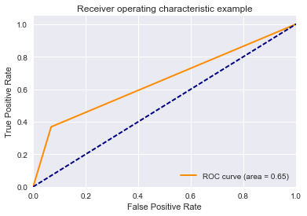

```python
y_score = clf_lg.predict(test_x)
fpr = dict()
tpr = dict()
roc_auc = dict()
fpr[0], tpr[0], _ = roc_curve(test_y, y_score)
roc_auc[0] = auc(fpr[0], tpr[0])
fpr["micro"], tpr["micro"], _ = roc_curve(test_y.ravel(), y_score.ravel())
roc_auc["micro"] = auc(fpr["micro"], tpr["micro"])

plt.figure()
lw = 2
plt.plot(fpr[0], tpr[0], color='darkorange',
         lw=lw, label='ROC curve (area = %0.2f)' % roc_auc[0])
plt.plot([0, 1], [0, 1], color='navy', lw=lw, linestyle='--')
plt.xlim([0.0, 1.0])
plt.ylim([0.0, 1.05])
plt.xlabel('False Positive Rate')
plt.ylabel('True Positive Rate')
plt.title('Receiver operating characteristic example')
plt.legend(loc="lower right")
plt.show()
```

Logistic Regression ROC Plot Above

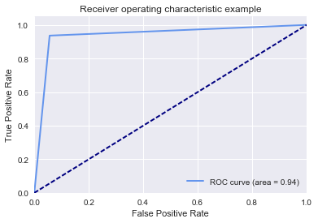

```python
y_score = clf_knn.predict(test_x)
fpr = dict()
tpr = dict()
roc_auc = dict()
fpr[0], tpr[0], _ = roc_curve(test_y, y_score)
roc_auc[0] = auc(fpr[0], tpr[0])
fpr["micro"], tpr["micro"], _ = roc_curve(test_y.ravel(), y_score.ravel())
roc_auc["micro"] = auc(fpr["micro"], tpr["micro"])

plt.figure()
lw = 2
plt.plot(fpr[0], tpr[0], color='cornflowerblue',
         lw=lw, label='ROC curve (area = %0.2f)' % roc_auc[0])
plt.plot([0, 1], [0, 1], color='navy', lw=lw, linestyle='--')
plt.xlim([0.0, 1.0])
plt.ylim([0.0, 1.05])
plt.xlabel('False Positive Rate')
plt.ylabel('True Positive Rate')
plt.title('Receiver operating characteristic example')
plt.legend(loc="lower right")
plt.show()
```

K-Nearest Neighbors ROC Plot Above

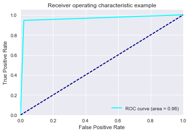

```python
y_score = clf_svm.predict(test_x)
fpr = dict()
tpr = dict()
roc_auc = dict()
fpr[0], tpr[0], _ = roc_curve(test_y, y_score)
roc_auc[0] = auc(fpr[0], tpr[0])
fpr["micro"], tpr["micro"], _ = roc_curve(test_y.ravel(), y_score.ravel())
roc_auc["micro"] = auc(fpr["micro"], tpr["micro"])

plt.figure()
lw = 2
plt.plot(fpr[0], tpr[0], color='aqua',
         lw=lw, label='ROC curve (area = %0.2f)' % roc_auc[0])
plt.plot([0, 1], [0, 1], color='navy', lw=lw, linestyle='--')
plt.xlim([0.0, 1.0])
plt.ylim([0.0, 1.05])
plt.xlabel('False Positive Rate')
plt.ylabel('True Positive Rate')
plt.title('Receiver operating characteristic example')
plt.legend(loc="lower right")
plt.show()
```

Support Vector Machine ROC Plot Above

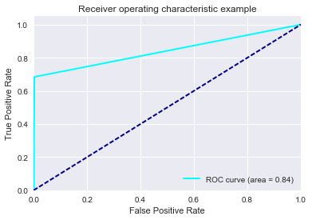

```python
y_score = clf_rf.predict(test_x)
fpr = dict()
tpr = dict()
roc_auc = dict()
fpr[0], tpr[0], _ = roc_curve(test_y, y_score)
roc_auc[0] = auc(fpr[0], tpr[0])
fpr["micro"], tpr["micro"], _ = roc_curve(test_y.ravel(), y_score.ravel())
roc_auc["micro"] = auc(fpr["micro"], tpr["micro"])

plt.figure()
lw = 2
plt.plot(fpr[0], tpr[0], color='aqua',
         lw=lw, label='ROC curve (area = %0.2f)' % roc_auc[0])
plt.plot([0, 1], [0, 1], color='navy', lw=lw, linestyle='--')
plt.xlim([0.0, 1.0])
plt.ylim([0.0, 1.05])
plt.xlabel('False Positive Rate')
plt.ylabel('True Positive Rate')
plt.title('Receiver operating characteristic example')
plt.legend(loc="lower right")
plt.show()
```

Random Forest ROC Plot Above

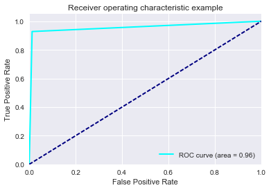

```python
y_score = gbm.predict(test_x)
fpr = dict()
tpr = dict()
roc_auc = dict()
fpr[0], tpr[0], _ = roc_curve(test_y, y_score)
roc_auc[0] = auc(fpr[0], tpr[0])
fpr["micro"], tpr["micro"], _ = roc_curve(test_y.ravel(), y_score.ravel())
roc_auc["micro"] = auc(fpr["micro"], tpr["micro"])

plt.figure()
lw = 2
plt.plot(fpr[0], tpr[0], color='aqua',
         lw=lw, label='ROC curve (area = %0.2f)' % roc_auc[0])
plt.plot([0, 1], [0, 1], color='navy', lw=lw, linestyle='--')
plt.xlim([0.0, 1.0])
plt.ylim([0.0, 1.05])
plt.xlabel('False Positive Rate')
plt.ylabel('True Positive Rate')
plt.title('Receiver operating characteristic example')
plt.legend(loc="lower right")
plt.show()
```

XGBoost ROC Plot Above

# 5.Summary

**2. Model**: Because our data is simulated, in this case, the tree algorithm and clustering algorithm showed their strenghts.

**3. To Improve**: I did not create any feature, because there are not many meaningful feature i can create. However, in feature average_monthly_hours, last_evaulation and satisfation_level there are some ranges have absolute low probability for left=0. We can bin these if necessary. Tree based models and clustering models work really good, they reach high AUC score in this case. We can create second level to reweight each model, however i do not think we need to do that, as XGBoost and SVM reach AUC=0.96 and KNN's AUC=0.94

**4. Overall**: It is a really interesting data set to work on.